# C题

现有一批我国古代玻璃制品的相关数据，考古工作者依据这些文物样品的化学成分和其他检测手段已将其分为高钾玻璃和铅钡玻璃两种类型。  
附件表单 1 给出了这些文物的分类信息  
附件表单 2 给出了相应的主要成分所占比例（空白处表示未检测到该成分）  
这些数据的特点是成分性，即各成分比例的累加和应为 100%，但因检测手段等原因可能导致其成分比例的累加和非100%的情况。  
本题中将成分比例累加和介于 85%~105%之间的数据视为有效数据。

```python
import numpy as np
import pandas as pd

from sklearn.neighbors import KNeighborsClassifier
from sklearn.model_selection import train_test_split

data_first = pd.read_excel('附件.xlsx', sheet_name='表单1')
data_second = pd.read_excel('附件.xlsx', sheet_name='表单2')

data_second=data_second.fillna(0)
#print(data_second.shape)

data_second_col1=data_second.iloc[:,0]
data_second_col=data_second.iloc[:,1:]
data_second_col['row_sum']=data_second_col.apply(lambda x: x.sum(),axis=1)

n=0
list=[]
for i in data_second_col.row_sum:
    if(i<85.00 or i>105.00):
        list.append(n)
    n=n+1

data_second=data_second.drop(index=list)
#data_second.shape

data_second_col1=data_second_col1.astype(str)

data_second_col1=data_second_col1.str.slice_replace(start=2, stop=None, repl=None)
data_second_col1

glass_type=data_first.iloc[:,[0,2]]
n=0
list1=[]
list2=[]
for i in glass_type['类型']:
    if(i=='高钾'):
        list1.append(n)
    n=n+1
#print(list1)

flag=False
data_second_col1=data_second_col1.astype(int)
for m in data_second_col1:
    for n in list1:
        if((m-1)==n):
            flag=True
            break
    if(flag):
        list2.append('高钾')
    else:
        list2.append('铅钡')
    flag=False

data_second['玻璃类型']=pd.Series(list2)

situation_type=data_first.iloc[:,[0,4]]
n=0
list1=[]
list2=[]
for i in situation_type['表面风化']:
    if(i=='无风化'):
        list1.append(n)
    n=n+1
#print(list1)

flag=False
data_second_col1=data_second_col1.astype(int)
for m in data_second_col1:
    for n in list1:
        if((m-1)==n):
            flag=True
            break
    if(flag):
        list2.append('无风化')
    else:
        list2.append('风化')
    flag=False

data_second['表面风化']=pd.Series(list2)
#data_second.to_csv('预处理.csv')
```

## 问题 1

1. 对这些玻璃文物的表面风化与其玻璃类型、纹饰和颜色的关系进行分析；

```python
from efficient_apriori import apriori

trans_list1=data_first.iloc[:,[1,4]].values.tolist()
trans_list2=data_first.iloc[:,[2,4]].values.tolist()

trans_list3=data_first.iloc[:,[3,4]]
trans_list3=trans_list3.dropna()
trans_list3=trans_list3.values.tolist()

itemsets,rules=apriori(trans_list1,min_support=0.1,min_confidence=0.7)
#itemsets是字典形式存储，键为频繁项集的元素个数，值也是一个字典（频繁项集为键，值为支持数）
print(itemsets,'\n')
#rules规则是以列表形式存储
print(rules)
```

```
{1: {('C',): 30, ('无风化',): 24, ('A',): 22, ('风化',): 34, ('B',): 6}, 2: {('A', '无风化'): 11, ('A', '风化'): 11, ('B', '风化'): 6, ('C', '无风化'): 13, ('C', '风化'): 17}}

[{B} -> {风化}]
```

```python
itemsets,rules=apriori(trans_list2,min_support=0.1,min_confidence=0.7)
#itemsets是字典形式存储，键为频繁项集的元素个数，值也是一个字典（频繁项集为键，值为支持数）
print(itemsets,'\n')
#rules规则是以列表形式存储
print(rules)
```

```
{1: {('高钾',): 18, ('无风化',): 24, ('铅钡',): 40, ('风化',): 34}, 2: {('无风化', '铅钡'): 12, ('无风化', '高钾'): 12, ('铅钡', '风化'): 28, ('风化', '高钾'): 6}}

[{风化} -> {铅钡}, {铅钡} -> {风化}]
```

```python
itemsets,rules=apriori(trans_list3,min_support=0.1,min_confidence=0.6)
#itemsets是字典形式存储，键为频繁项集的元素个数，值也是一个字典（频繁项集为键，值为支持数）
print(itemsets,'\n')
#rules规则是以列表形式存储
print(rules)
```

```
{1: {('蓝绿',): 15, ('无风化',): 24, ('浅蓝',): 20, ('风化',): 30, ('深绿',): 7}, 2: {('无风化', '浅蓝'): 8, ('无风化', '蓝绿'): 6, ('浅蓝', '风化'): 12, ('蓝绿', '风化'): 9}}

[{浅蓝} -> {风化}, {蓝绿} -> {风化}]
```

```python
from mlxtend.frequent_patterns import apriori,association_rules
from mlxtend.preprocessing import TransactionEncoder

TE=TransactionEncoder()
trans_new=TE.fit_transform(trans_list1)
trans_new=pd.DataFrame(trans_new,columns=TE.columns_)

frequent_itemset = apriori(trans_new,min_support=0.1,use_colnames=True)
frequent_itemset.sort_values(by='support',ascending=True)

rules_mlxtend=association_rules(frequent_itemset,metric='confidence',min_threshold=0.7)
rules_mlxtend
```

|  | antecedents | consequents | antecedent support | consequent support | support | confidence | lift | leverage | conviction |
| --- | --- | --- | --- | --- | --- | --- | --- | --- | --- |
| 0 | (B) | (风化) | 0.103448 | 0.586207 | 0.103448 | 1.0 | 1.705882 | 0.042806 | inf |

```python
TE=TransactionEncoder()
trans_new=TE.fit_transform(trans_list2)
trans_new=pd.DataFrame(trans_new,columns=TE.columns_)

frequent_itemset = apriori(trans_new,min_support=0.1,use_colnames=True)
frequent_itemset.sort_values(by='support',ascending=True)

rules_mlxtend=association_rules(frequent_itemset,metric='confidence',min_threshold=0.7)
rules_mlxtend
```

|  | antecedents | consequents | antecedent support | consequent support | support | confidence | lift | leverage | conviction |
| --- | --- | --- | --- | --- | --- | --- | --- | --- | --- |
| 0 | (铅钡) | (风化) | 0.689655 | 0.586207 | 0.482759 | 0.700000 | 1.194118 | 0.078478 | 1.379310 |
| 1 | (风化) | (铅钡) | 0.586207 | 0.689655 | 0.482759 | 0.823529 | 1.194118 | 0.078478 | 1.758621 |

```python
TE=TransactionEncoder()
trans_new=TE.fit_transform(trans_list3)
trans_new=pd.DataFrame(trans_new,columns=TE.columns_)

frequent_itemset = apriori(trans_new,min_support=0.1,use_colnames=True)
frequent_itemset.sort_values(by='support',ascending=True)

rules_mlxtend=association_rules(frequent_itemset,metric='confidence',min_threshold=0.6)
rules_mlxtend
```

|  | antecedents | consequents | antecedent support | consequent support | support | confidence | lift | leverage | conviction |
| --- | --- | --- | --- | --- | --- | --- | --- | --- | --- |
| 0 | (浅蓝) | (风化) | 0.370370 | 0.555556 | 0.222222 | 0.6 | 1.08 | 0.016461 | 1.111111 |
| 1 | (蓝绿) | (风化) | 0.277778 | 0.555556 | 0.166667 | 0.6 | 1.08 | 0.012346 | 1.111111 |

## 问题1

1. 结合玻璃的类型，分析文物样品表面有无风化化学成分含量的统计规律(SPSS独立样本T检验)

## 问题1

1. 并根据风化点检测数据，预测其风化前的化学成分含量。

```python
sheet2=pd.read_csv("再次处理.csv")
sheet2=sheet2.iloc[:,1:17]
sheet2=sheet2.drop('玻璃类型',axis=1)
sheet2=sheet2.groupby('情况')

describe = pd.DataFrame(sheet2.describe().values.T, index=sheet2.describe().columns, columns=sheet2.describe().index)
print(describe.shape)

list=[]
for i in range(14):
    n=1+i*8
    list.append(n)

mean_content=describe.iloc[list,:]

#print(mean_content.index)
new_index=['0','1','2','3','4','5','6','7','8','9','10','11','12','13']
mean_content.index=new_index
new_columns=['二氧化硅SiO2','氧化钠Na2O','氧化钾K2O','氧化钙CaO','氧化镁MgO','氧化铝Al2O3','氧化铁Fe2O3','氧化铜CuO','氧化铅PbO','氧化钡BaO','五氧化二磷P2O5','氧化锶SrO','氧化锡SnO2','二氧化硫SO2']
mean_content['化学成分']=new_columns
#print(mean_content.head)

list=[]
for i in new_index:
    i=int(i)
    list.append(mean_content.iloc[i,0]/mean_content.iloc[i,1])
print(list)

sheet2=pd.read_csv("再次处理.csv")
sheet2=sheet2.iloc[:,1:17]
sheet2=sheet2.drop('玻璃类型',axis=1)

situation0=sheet2[sheet2['情况']=='风化']
predict_content=pd.DataFrame()
#print(situation0.iloc[:,0])
for i in range(14):
    predict_content[new_columns[i]]=situation0.iloc[:,i]*list[i]
predict_content

#predict_content 为预测 风化点 未风化时的化学成分
```

```
(112, 2)
[1.5644080527606046, 7.6526690391459065, 15.89471449798344, 1.1457104913678622, 1.3997471554993677, 1.8731531531531527, 2.1847017782693787, 0.8318479303013881, 0.41639553882219227, 0.6379956536508866, 0.26963167151805645, 0.5605042016806722, 1.7617977528089885, 0.12561132561132562]
```

|  | 二氧化硅SiO2 | 氧化钠Na2O | 氧化钾K2O | 氧化钙CaO | 氧化镁MgO | 氧化铝Al2O3 | 氧化铁Fe2O3 | 氧化铜CuO | 氧化铅PbO | 氧化钡BaO | 五氧化二磷P2O5 | 氧化锶SrO | 氧化锡SnO2 | 二氧化硫SO2 |
| --- | --- | --- | --- | --- | --- | --- | --- | --- | --- | --- | --- | --- | --- | --- |
| 1 | 56.756724 | 0.000000 | 16.689450 | 2.680963 | 1.651702 | 10.733168 | 4.063545 | 0.216280 | 19.749640 | 0.000000 | 0.962585 | 0.106496 | 0.000000 | 0.000000 |
| 8 | 144.911118 | 0.000000 | 0.000000 | 1.225910 | 0.000000 | 3.708843 | 0.371399 | 2.695187 | 0.000000 | 0.000000 | 0.164475 | 0.000000 | 0.000000 | 0.000000 |
| 9 | 31.507178 | 0.000000 | 0.000000 | 1.695652 | 0.000000 | 2.510025 | 0.000000 | 8.659537 | 11.942224 | 19.924604 | 0.967978 | 0.207387 | 0.000000 | 0.324077 |
| 10 | 7.211921 | 0.000000 | 0.000000 | 3.654816 | 0.000000 | 2.079200 | 0.000000 | 2.612003 | 13.512035 | 19.535427 | 2.038415 | 0.297067 | 0.000000 | 1.887938 |
| 11 | 148.650053 | 0.000000 | 9.377882 | 0.710341 | 0.000000 | 2.472562 | 0.699105 | 1.289364 | 0.000000 | 0.000000 | 0.094371 | 0.000000 | 0.000000 | 0.000000 |
| 12 | 151.387767 | 0.000000 | 14.623137 | 0.240599 | 0.000000 | 1.517254 | 0.568022 | 0.698752 | 0.000000 | 0.000000 | 0.000000 | 0.000000 | 0.000000 | 0.000000 |
| 13 | 52.548466 | 0.000000 | 3.337890 | 4.021444 | 0.993820 | 5.038782 | 0.000000 | 4.101010 | 10.572283 | 9.321116 | 2.529145 | 0.207387 | 0.000000 | 0.000000 |
| 14 | 147.508035 | 0.000000 | 16.053662 | 0.824912 | 0.000000 | 2.734804 | 0.633564 | 1.372549 | 0.000000 | 0.000000 | 0.040445 | 0.000000 | 0.000000 | 0.000000 |
| 19 | 46.369055 | 0.000000 | 0.000000 | 3.356932 | 0.825851 | 6.687157 | 2.905653 | 2.919786 | 17.830057 | 3.413277 | 2.380848 | 0.106496 | 0.000000 | 0.000000 |
| 22 | 144.473084 | 0.000000 | 11.762089 | 1.901879 | 0.895838 | 6.556036 | 0.764646 | 0.457516 | 0.000000 | 0.000000 | 0.056623 | 0.000000 | 0.000000 | 0.000000 |
| 26 | 30.959635 | 0.000000 | 0.000000 | 1.649823 | 0.000000 | 1.311207 | 0.000000 | 8.792633 | 12.296160 | 20.575360 | 0.843947 | 0.252227 | 0.000000 | 0.246198 |
| 27 | 5.819598 | 0.000000 | 6.357886 | 3.448589 | 0.000000 | 2.210321 | 0.000000 | 2.994653 | 12.458555 | 22.616946 | 1.628575 | 0.347513 | 0.000000 | 2.003501 |
| 28 | 145.051915 | 0.000000 | 0.000000 | 1.076968 | 0.755863 | 4.701614 | 0.436940 | 1.281046 | 0.000000 | 0.000000 | 0.097067 | 0.000000 | 0.000000 | 0.000000 |
| 36 | 55.974520 | 0.000000 | 3.973679 | 0.893654 | 0.000000 | 3.034508 | 1.026810 | 1.256090 | 19.383212 | 6.379957 | 0.091675 | 0.123311 | 0.000000 | 0.000000 |
| 38 | 61.903627 | 16.988925 | 2.225260 | 0.423913 | 0.000000 | 2.997045 | 0.699105 | 0.565657 | 17.326218 | 6.909493 | 0.018874 | 0.123311 | 0.000000 | 0.000000 |
| 40 | 51.515957 | 10.560683 | 0.000000 | 0.779083 | 0.000000 | 4.814004 | 0.633564 | 0.607249 | 20.532464 | 6.245977 | 0.129423 | 0.229807 | 0.000000 | 0.000000 |
| 41 | 41.065711 | 0.000000 | 0.000000 | 1.271739 | 0.000000 | 0.936577 | 0.000000 | 0.732026 | 25.412620 | 4.606329 | 0.312773 | 0.341908 | 0.000000 | 0.000000 |
| 42 | 26.141259 | 0.000000 | 0.000000 | 2.142479 | 0.000000 | 0.842919 | 0.415093 | 0.000000 | 29.235131 | 4.268191 | 0.477248 | 0.381143 | 0.000000 | 0.000000 |
| 43 | 28.878973 | 0.000000 | 6.993674 | 5.682724 | 3.821310 | 6.237600 | 3.910616 | 0.158051 | 18.371371 | 6.226838 | 2.011452 | 0.263437 | 0.000000 | 0.000000 |
| 46 | 19.414304 | 0.000000 | 0.000000 | 6.003523 | 1.245775 | 4.214595 | 1.660373 | 4.450386 | 24.921273 | 4.650988 | 0.000000 | 0.358723 | 0.000000 | 0.000000 |
| 47 | 33.947655 | 0.000000 | 0.000000 | 7.332547 | 1.329760 | 6.387452 | 3.036735 | 1.256090 | 18.633700 | 2.079866 | 3.459374 | 0.263437 | 0.000000 | 0.000000 |
| 52 | 83.429881 | 6.122135 | 5.086309 | 3.230904 | 2.155611 | 25.568541 | 2.250243 | 0.000000 | 6.541574 | 4.663748 | 0.296595 | 0.140126 | 2.307955 | 0.000000 |
| 53 | 45.039308 | 0.000000 | 0.000000 | 5.247354 | 2.057628 | 10.077564 | 5.986083 | 0.582294 | 14.232400 | 3.891773 | 2.992912 | 0.257832 | 0.000000 | 0.000000 |
| 55 | 28.128057 | 0.000000 | 0.000000 | 3.654816 | 0.657881 | 3.502796 | 0.720952 | 0.939988 | 18.321404 | 9.059538 | 1.709465 | 0.369933 | 0.000000 | 0.000000 |
| 57 | 38.500082 | 0.000000 | 0.000000 | 4.101644 | 1.665699 | 9.834054 | 2.599795 | 1.139632 | 16.755756 | 5.703681 | 2.184017 | 0.218597 | 0.828045 | 0.000000 |
| 58 | 33.400112 | 0.000000 | 0.000000 | 5.877495 | 2.029633 | 4.701614 | 0.917575 | 0.623886 | 21.377747 | 0.000000 | 2.359277 | 0.000000 | 0.000000 | 0.000000 |
| 59 | 40.267863 | 9.336256 | 0.000000 | 2.600763 | 0.769861 | 2.172858 | 0.502481 | 0.582294 | 19.745476 | 5.512282 | 1.539597 | 0.246622 | 0.000000 | 0.000000 |
| 61 | 34.855011 | 0.000000 | 5.086309 | 3.654816 | 1.791676 | 7.773586 | 0.000000 | 0.690434 | 23.093297 | 4.491489 | 1.143238 | 0.493244 | 0.000000 | 0.000000 |
| 62 | 26.767022 | 0.000000 | 0.000000 | 0.000000 | 1.553719 | 6.837009 | 0.000000 | 1.114676 | 24.342483 | 0.000000 | 3.809896 | 0.627765 | 0.000000 | 0.000000 |
| 64 | 45.602495 | 0.000000 | 0.000000 | 1.386310 | 0.000000 | 3.465333 | 0.000000 | 0.657160 | 17.176316 | 9.857033 | 0.684864 | 0.000000 | 0.000000 | 0.000000 |
| 65 | 39.767253 | 0.000000 | 0.000000 | 1.500881 | 0.000000 | 4.083474 | 0.000000 | 0.964944 | 18.779439 | 11.037325 | 0.000000 | 0.000000 | 0.000000 | 0.000000 |
| 66 | 47.542361 | 0.000000 | 5.404203 | 3.998530 | 1.105800 | 6.593499 | 1.878844 | 2.603684 | 16.385164 | 4.887047 | 2.423989 | 0.134521 | 0.000000 | 0.000000 |

## 问题2

1. 依据附件数据分析高钾玻璃、铅钡玻璃的分类规律【二元Logistic回归 SPSS】

```python
from factor_analyzer.factor_analyzer import calculate_bartlett_sphericity

# Bartlett's球状检验
sheet2=pd.read_csv("高钾.csv")
sheet2_data=sheet2.iloc[:,1:15]
sheet2_target=sheet2.iloc[:,15]


chi_square_value, p_value = calculate_bartlett_sphericity(sheet2_data)
print('高钾的Bartlett球状检验',chi_square_value, p_value)

# KMO检验
# 检查变量间的相关性和偏相关性，取值在0-1之间；KOM统计量越接近1，变量间的相关性越强，偏相关性越弱，因子分析的效果越好。
# 通常取值从0.6开始进行因子分析
from factor_analyzer.factor_analyzer import calculate_kmo

kmo_all, kmo_model = calculate_kmo(sheet2_data)
print('高钾的KMO检验参数\n',kmo_all)
print(kmo_all.mean())
```

```
高钾的Bartlett球状检验 301.82238648039987 2.0572209838329385e-24
高钾的KMO检验参数
 [0.42184342 0.31598576 0.3242153  0.38765127 0.41233268 0.44568571
 0.41857216 0.21150246 0.3795262  0.4129849  0.61476325 0.51746695
 0.13147082 0.26823338]
0.37587387616096574
```

```python
# Bartlett's球状检验
sheet2=pd.read_csv("铅钡.csv")
sheet2_data=sheet2.iloc[:,1:15]
sheet2_target=sheet2.iloc[:,15]


chi_square_value, p_value = calculate_bartlett_sphericity(sheet2_data)
print('铅钡的Bartlett球状检验',chi_square_value, p_value)

# KMO检验
# 检查变量间的相关性和偏相关性，取值在0-1之间；KOM统计量越接近1，变量间的相关性越强，偏相关性越弱，因子分析的效果越好。
# 通常取值从0.6开始进行因子分析
from factor_analyzer.factor_analyzer import calculate_kmo

kmo_all, kmo_model = calculate_kmo(sheet2_data)
print('铅钡的KMO检验参数\n',kmo_all)
print(kmo_all.mean())
```

```
铅钡的Bartlett球状检验 416.38076777258703 4.0671782237096744e-43
铅钡的KMO检验参数
 [0.33163859 0.20350478 0.66741036 0.46400089 0.68247364 0.31168378
 0.41782129 0.64964166 0.23352227 0.28438094 0.23601891 0.5325607
 0.68804712 0.47295071]
0.4411182611703182
```

KMO校验值较低，不适用主成分分析与因子分析法

## 问题2

1. 对于每个类别选择合适的化学成分对其进行亚类划分，给出具体的划分方法及划分结果，并对分类结果的合理性和敏感性进行分析。

```python
import pandas as pd
import numpy as np
import matplotlib.pyplot as plt
from matplotlib.colors import ListedColormap
from sklearn.neighbors import KNeighborsClassifier
from sklearn.model_selection import train_test_split

classify_data=pd.read_csv("最终数据.csv")

data_a = classify_data.iloc[:18,1:15]
data_b = classify_data.iloc[18:,1:15]
```

### 先使用 高钾 的化学成分数据 进行PCA 降维

```
[92.7 96.3 98.  99.  99.4 99.6 99.8]
```

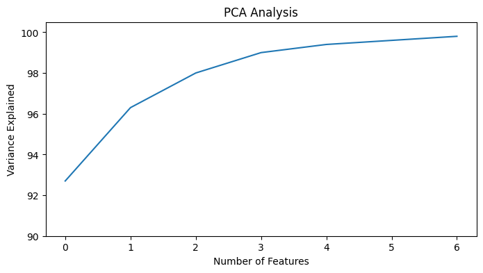

```python
from sklearn.decomposition import PCA

pca = PCA(n_components=7)
pca.fit(data_a) #使用高钾进行PCA降维
variance = pca.explained_variance_ratio_
var = np.cumsum(np.round(variance,3)*100)
print(var)
plt.figure(figsize=(8,4))
plt.ylabel('Variance Explained')
plt.xlabel('Number of Features')
plt.title('PCA Analysis')
plt.ylim(90,100.5)
plt.plot(var)
```

由上图得：排名最前的三个主成分已经可以解释98%的数据，所以以下选择PCA降成3维

```python
pca = PCA(n_components=3)
pca.fit(data_a)
pca_trans = pca.transform(data_a)
pca_df = pd.DataFrame(pca_trans, columns=['component1', 'component2', 'component3'])
pca_df.head()
```

|  | component1 | component2 | component3 |
| --- | --- | --- | --- |
| 0 | -8.128817 | -2.052005 | -1.378487 |
| 1 | 10.607137 | -1.549880 | 1.458374 |
| 2 | -16.152699 | -1.091205 | -0.596851 |
| 3 | -11.697599 | -0.539224 | -0.969425 |
| 4 | -16.336917 | 0.024592 | -0.864405 |

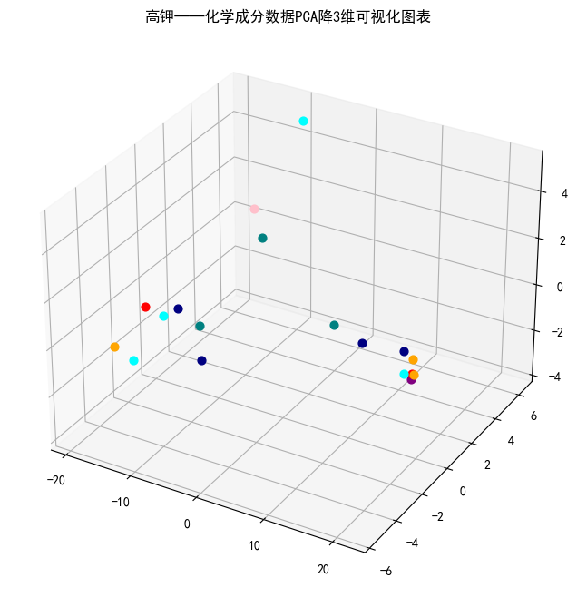

```python
plt.rcParams['axes.unicode_minus']=False #用来正常显示负号
plt.rcParams['font.sans-serif']=['SimHei'] #显示中文

import random

fig = plt.figure(figsize=(12,8))
ax = fig.add_subplot(111, projection='3d')
color = ['yellow','black','aqua','green','teal','orange','navy','pink','purple','red']
for x in range(0,18):
    ax.scatter(pca_df.iloc[x,0],pca_df.iloc[x,1],pca_df.iloc[x,2],color=color[random.randint(0,9)],marker='o',s=40)
plt.title('高钾——化学成分数据PCA降3维可视化图表')
```

#### K-Means聚类

```
轮廓系数为： [0.6514641695284811, 0.5715250635027108, 0.44608029137320365, 0.41077750551279696, 0.343227902971504]
calinski_harabasz系数为： [65.12413765971121, 60.08885909855051, 50.21754909162088, 44.627597262782444, 45.90725945840063]
inertia指标为： [810.4570201189017, 420.9231651057482, 308.21029268757565, 231.19363589914923, 151.18326969680425]
```

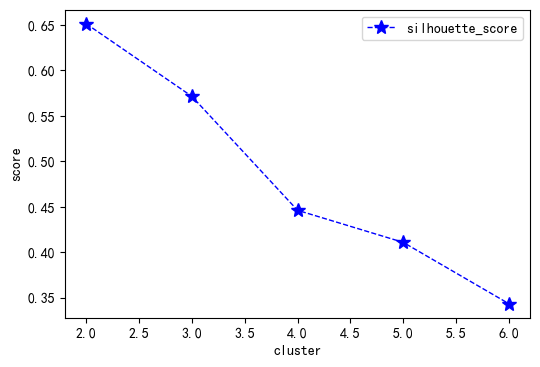

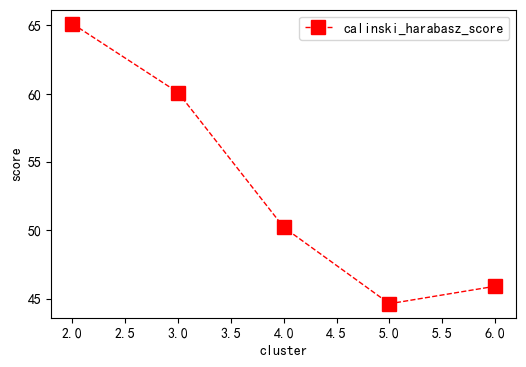

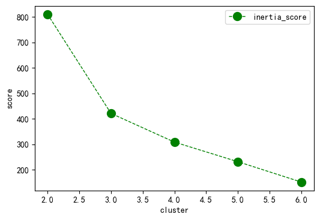

```python
from sklearn.cluster import KMeans
from sklearn.metrics import silhouette_score
from sklearn.metrics import calinski_harabasz_score

silh_score=[]
cali_score=[]
inertia_score=[]

def new_func(kmeans):
    return kmeans.inertia_

for i in range(2,7):
    kmeans=KMeans(n_clusters=i,random_state=123).fit(pca_trans)
    score=silhouette_score(data_a,kmeans.labels_)
    silh_score.append(score)
    score=calinski_harabasz_score(data_a,kmeans.labels_)
    cali_score.append(score)
    score=new_func(kmeans)
    inertia_score.append(score)

print('轮廓系数为：',silh_score)
print('calinski_harabasz系数为：',cali_score)
print('inertia指标为：',inertia_score)  #inertia表示的是每个样本点到其所在质心的距离之和

plt.figure(figsize=(6,4))
plt.plot(range(2,7),silh_score,'b*--',linewidth=1,markersize=10,label='silhouette_score')
plt.legend()
plt.xlabel('cluster')
plt.ylabel('score')
plt.show()

plt.figure(figsize=(6,4))
plt.plot(range(2,7),cali_score,'rs--',linewidth=1,markersize=10,label='calinski_harabasz_score')
plt.legend()
plt.xlabel('cluster')
plt.ylabel('score')
plt.show()

plt.figure(figsize=(6,4))
plt.plot(range(2,7),inertia_score,'go--',linewidth=1,markersize=10,label='inertia_score')
plt.legend()
plt.xlabel('cluster')
plt.ylabel('score')
plt.show()
```

综合三张评价系数图表，选择聚类的个数为3

```
'原始数据集K-Means聚类后质心为'
```

|  | 0 | 1 | 2 | 3 | 4 | 5 | 6 | 7 | 8 | 9 | 10 | 11 | 12 | 13 |
| --- | --- | --- | --- | --- | --- | --- | --- | --- | --- | --- | --- | --- | --- | --- |
| 0 | 63.624444 | 9.266667e-01 | 10.817778 | 6.363333 | 1.133333 | 7.348889 | 2.312222 | 2.818889 | 0.410000 | 5.788889e-01 | 1.523333 | 4.777778e-02 | 0.000000e+00 | 0.135556 |
| 1 | 92.975714 | 5.551115e-17 | 1.207143 | 1.032857 | 0.168571 | 2.234286 | 0.227143 | 1.450000 | 0.035714 | 5.551115e-17 | 0.334286 | -3.469447e-18 | 2.775558e-17 | 0.000000 |
| 2 | 78.070000 | 0.000000e+00 | 4.710000 | 2.355000 | 1.375000 | 4.620000 | 1.185000 | 1.640000 | 0.500000 | 9.850000e-01 | 1.230000 | 3.500000e-02 | 1.180000e+00 | 0.000000 |

```
'PCA降维,K-Means聚类后质心为'
```

|  | 0 | 1 | 2 |
| --- | --- | --- | --- |
| 0 | -14.231373 | -0.104410 | 0.005034 |
| 1 | 18.857204 | -0.012200 | -0.483423 |
| 2 | 4.979710 | 0.337631 | 0.951742 |

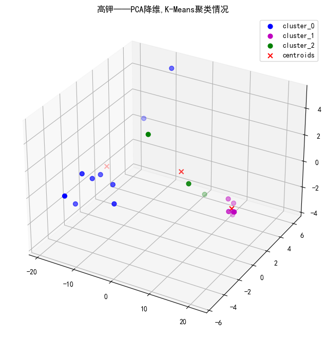

```python
kmeans_row=KMeans(n_clusters=3,random_state=123).fit(data_a)
centroids_row=pd.DataFrame(kmeans_row.cluster_centers_)
display("原始数据集K-Means聚类后质心为",centroids_row)

kmeans=KMeans(n_clusters=3,random_state=123).fit(pca_trans)
centroids=pd.DataFrame(kmeans.cluster_centers_)
display("PCA降维,K-Means聚类后质心为",centroids)

pca_df['label']=kmeans.labels_
cluster_0=pca_df[pca_df['label']==0]
cluster_1=pca_df[pca_df['label']==1]
cluster_2=pca_df[pca_df['label']==2]

fig = plt.figure(figsize=(16,8))
ax = fig.add_subplot(111, projection='3d')
ax.scatter(cluster_0.iloc[:,0],cluster_0.iloc[:,1],cluster_0.iloc[:,2],c='b',label='cluster_0',s=40)
ax.scatter(cluster_1.iloc[:,0],cluster_1.iloc[:,1],cluster_1.iloc[:,2],c='m',label='cluster_1',s=40)
ax.scatter(cluster_2.iloc[:,0],cluster_2.iloc[:,1],cluster_2.iloc[:,2],c='g',label='cluster_2',s=40)
ax.scatter(centroids.iloc[:,0],centroids.iloc[:,1],centroids.iloc[:,2],marker='x',color='red',label='centroids',s=40)

plt.title('高钾——PCA降维,K-Means聚类情况')
plt.legend()
plt.show()
```

#### 建立高钾DBSCAN聚类模型、评价聚类模型选择最优聚类簇数目

```python
from sklearn.cluster import DBSCAN

for i in np.arange(6.8,9,0.3):
    for j in np.arange(2,4):
        DB=DBSCAN(eps=i,min_samples=j).fit(pca_trans)
        labels=DB.labels_
        n_clusters_=len(set(labels))-(1 if -1 in labels else 0)
        n_noise_=labels.tolist().count(-1)
        if n_clusters_ <= 5 and n_noise_ <= 5:
            print("参数eps={},min_samples={}".format(i,j))
            print("聚类之后的簇数目有{}个,噪声数据有{}个".format(n_clusters_,n_noise_))
            print("分类标签为：",labels)
            silh_score=silhouette_score(pca_trans,DB.labels_)
            cali_score=calinski_harabasz_score(pca_trans,DB.labels_)
            print("silhouette方法得分为{}".format(silh_score))
            print("calinski_harabasz方法得分为{}".format(cali_score))
            print("\n---------------------------------------\n")
```

```
参数eps=6.8,min_samples=2
聚类之后的簇数目有2个,噪声数据有4个
分类标签为： [ 0 -1  0  0  0 -1  0  1  1  1  1  0  0  0 -1 -1  1  1]
silhouette方法得分为0.5683750328839111
calinski_harabasz方法得分为58.63208550119446

---------------------------------------

参数eps=6.8,min_samples=3
聚类之后的簇数目有2个,噪声数据有4个
分类标签为： [ 0 -1  0  0  0 -1  0  1  1  1  1  0  0  0 -1 -1  1  1]
silhouette方法得分为0.5683750328839111
calinski_harabasz方法得分为58.63208550119446

---------------------------------------

参数eps=7.1,min_samples=2
聚类之后的簇数目有2个,噪声数据有3个
分类标签为： [ 0  1  0  0  0 -1  0  1  1  1  1  0  0  0 -1 -1  1  1]
silhouette方法得分为0.5751285416476584
calinski_harabasz方法得分为68.02868048756369

---------------------------------------

参数eps=7.1,min_samples=3
聚类之后的簇数目有2个,噪声数据有3个
分类标签为： [ 0  1  0  0  0 -1  0  1  1  1  1  0  0  0 -1 -1  1  1]
silhouette方法得分为0.5751285416476584
calinski_harabasz方法得分为68.02868048756369

---------------------------------------

参数eps=7.3999999999999995,min_samples=2
聚类之后的簇数目有2个,噪声数据有3个
分类标签为： [ 0  1  0  0  0 -1  0  1  1  1  1  0  0  0 -1 -1  1  1]
silhouette方法得分为0.5751285416476584
calinski_harabasz方法得分为68.02868048756369

---------------------------------------

```

[output cut: 72 more lines]

```
参数eps=8.899999999999999,min_samples=2
聚类之后的簇数目有2个,噪声数据有2个
分类标签为： [ 0  1  0  0  0 -1  0  1  1  1  1  0  0  0  1 -1  1  1]
silhouette方法得分为0.5219714047858646
calinski_harabasz方法得分为50.79103864936658

---------------------------------------

参数eps=8.899999999999999,min_samples=3
聚类之后的簇数目有2个,噪声数据有2个
分类标签为： [ 0  1  0  0  0 -1  0  1  1  1  1  0  0  0  1 -1  1  1]
silhouette方法得分为0.5219714047858646
calinski_harabasz方法得分为50.79103864936658

---------------------------------------
```

综合两种参数指标，参数 eps=7.1 , min_samples=2 的组合效果最优  
聚类之后的簇数目有2个,噪声数据有3个  
silhouette方法得分为0.5751285416476584  
calinski_harabasz方法得分为68.02868048756369

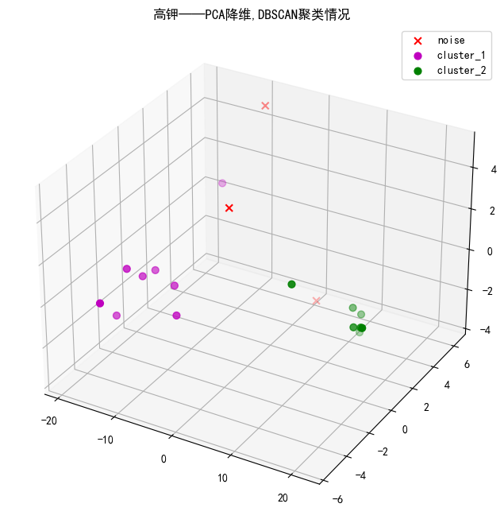

```python
DB=DBSCAN(eps=7.1,min_samples=2).fit(pca_trans)
pca_df['label']=DB.labels_
cluster_0=pca_df[pca_df['label']==(-1)]
cluster_1=pca_df[pca_df['label']==0]
cluster_2=pca_df[pca_df['label']==1]

fig = plt.figure(figsize=(16,8))
ax = fig.add_subplot(111, projection='3d')
ax.scatter(cluster_0.iloc[:,0],cluster_0.iloc[:,1],cluster_0.iloc[:,2],marker='x',color='red',label='noise',s=40)
ax.scatter(cluster_1.iloc[:,0],cluster_1.iloc[:,1],cluster_1.iloc[:,2],c='m',label='cluster_1',s=40)
ax.scatter(cluster_2.iloc[:,0],cluster_2.iloc[:,1],cluster_2.iloc[:,2],c='g',label='cluster_2',s=40)

plt.title('高钾——PCA降维,DBSCAN聚类情况')
plt.legend()
plt.show()
```

### 再使用 铅钡 的化学成分数据 进行PCA 降维

```
[74.5 93.2 96.9 97.9 98.8 99.3 99.6]
```

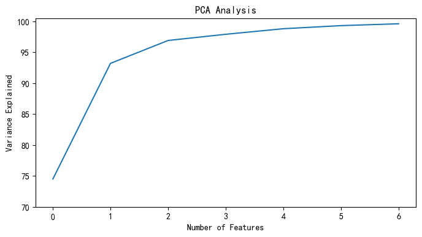

```python
pca = PCA(n_components=7)
pca.fit(data_b) #使用铅钡进行PCA降维
variance = pca.explained_variance_ratio_
var = np.cumsum(np.round(variance,3)*100)
print(var)
plt.figure(figsize=(8,4))
plt.ylabel('Variance Explained')
plt.xlabel('Number of Features')
plt.title('PCA Analysis')
plt.ylim(70,100.5)
plt.plot(var)
```

由上图得：排名最前的五个主成分已经可以解释98.8%的数据，所以以下选择PCA降成5维

```python
pca = PCA(n_components=5)
pca.fit(data_b)
pca_trans = pca.transform(data_b)
pca_df = pd.DataFrame(pca_trans, columns=['component1', 'component2', 'component3','component4','component5'])
pca_df.head()
```

|  | component1 | component2 | component3 | component4 | component5 |
| --- | --- | --- | --- | --- | --- |
| 0 | -8.953808 | -15.261436 | 1.789723 | 1.778807 | 1.298221 |
| 1 | -14.944155 | 24.751067 | -4.556961 | -0.413522 | -4.819146 |
| 2 | -30.197515 | 28.566028 | 2.164642 | -1.633019 | 8.686816 |
| 3 | -0.818506 | 9.924134 | 5.822540 | -3.444166 | -3.573933 |
| 4 | -12.888798 | -5.939519 | 4.938241 | -2.146144 | -1.696434 |

#### K-Means聚类

```
轮廓系数为： [0.5119292021250728, 0.510976667859331, 0.391865729751237, 0.32457552783973037, 0.3631543034085193]
calinski_harabasz系数为： [71.85730416970063, 63.263797077520735, 55.36497669863502, 54.51636989737436, 55.77067395487239]
inertia指标为： [12685.953910056349, 8438.939449926063, 6683.7455458877375, 5220.010005452497, 4103.589314716419]
```

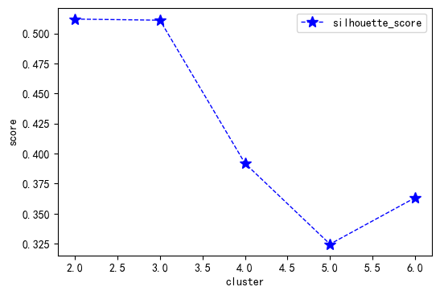

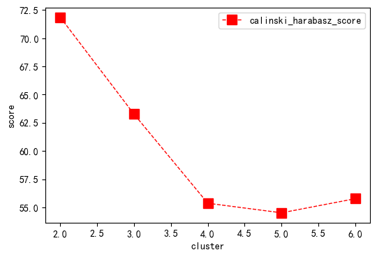

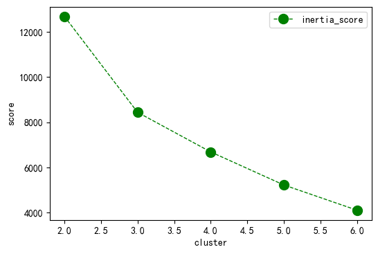

```python
from sklearn.cluster import KMeans
from sklearn.metrics import silhouette_score
from sklearn.metrics import calinski_harabasz_score

silh_score=[]
cali_score=[]
inertia_score=[]

for i in range(2,7):
    kmeans=KMeans(n_clusters=i,random_state=123).fit(pca_trans)
    score=silhouette_score(data_b,kmeans.labels_)
    silh_score.append(score)
    score=calinski_harabasz_score(data_b,kmeans.labels_)
    cali_score.append(score)
    score=kmeans.inertia_
    inertia_score.append(score)

print('轮廓系数为：',silh_score)
print('calinski_harabasz系数为：',cali_score)
print('inertia指标为：',inertia_score)  #inertia表示的是每个样本点到其所在质心的距离之和

plt.figure(figsize=(6,4))
plt.plot(range(2,7),silh_score,'b*--',linewidth=1,markersize=10,label='silhouette_score')
plt.legend()
plt.xlabel('cluster')
plt.ylabel('score')
plt.show()

plt.figure(figsize=(6,4))
plt.plot(range(2,7),cali_score,'rs--',linewidth=1,markersize=10,label='calinski_harabasz_score')
plt.legend()
plt.xlabel('cluster')
plt.ylabel('score')
plt.show()

plt.figure(figsize=(6,4))
plt.plot(range(2,7),inertia_score,'go--',linewidth=1,markersize=10,label='inertia_score')
plt.legend()
plt.xlabel('cluster')
plt.ylabel('score')
plt.show()
```

综合三张评价系数图表，选择聚类的个数为3

```
'原始数据集K-Means聚类后质心为'
```

|  | 0 | 1 | 2 | 3 | 4 | 5 | 6 | 7 | 8 | 9 | 10 | 11 | 12 | 13 |
| --- | --- | --- | --- | --- | --- | --- | --- | --- | --- | --- | --- | --- | --- | --- |
| 0 | 58.496500 | 1.975000 | 0.161500 | 1.199500 | 0.739000 | 5.044500 | 0.580000 | 0.984500 | 20.413000 | 7.196500 | 0.896500 | 0.234000 | 7.700000e-02 | 0.183000 |
| 1 | 21.592857 | 0.000000 | 0.188571 | 1.871429 | 0.101429 | 2.008571 | 0.215714 | 6.555714 | 26.344286 | 27.705714 | 5.084286 | 0.464286 | 6.938894e-18 | 5.074286 |
| 2 | 26.537273 | 0.219091 | 0.179545 | 2.880000 | 0.733636 | 2.943636 | 0.865000 | 1.205455 | 47.338182 | 8.007273 | 4.900909 | 0.414545 | 5.954545e-02 | 0.000000 |

```
'PCA降维,K-Means聚类后质心为'
```

|  | 0 | 1 | 2 | 3 | 4 |
| --- | --- | --- | --- | --- | --- |
| 0 | 23.916271 | -1.202269 | -0.216437 | 0.036968 | 0.467545 |
| 1 | -12.170011 | 23.252480 | -0.759298 | -0.867127 | -0.761001 |
| 2 | -17.869788 | -6.305544 | 0.438356 | 0.242297 | -0.182904 |

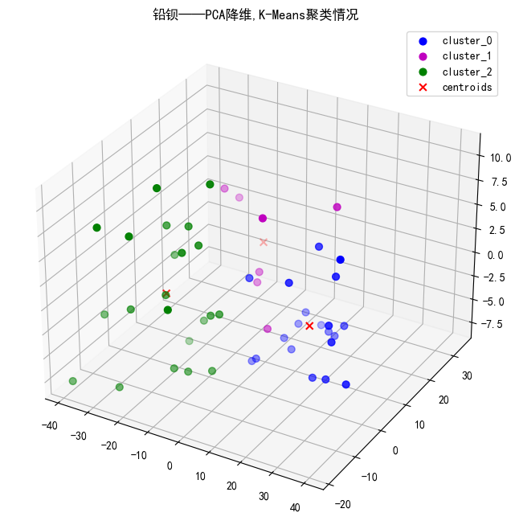

```python
kmeans_row=KMeans(n_clusters=3,random_state=123).fit(data_b)
centroids_row=pd.DataFrame(kmeans_row.cluster_centers_)
display("原始数据集K-Means聚类后质心为",centroids_row)

kmeans=KMeans(n_clusters=3,random_state=123).fit(pca_trans)
centroids=pd.DataFrame(kmeans.cluster_centers_)
display("PCA降维,K-Means聚类后质心为",centroids)

pca_df['label']=kmeans.labels_
cluster_0=pca_df[pca_df['label']==0]
cluster_1=pca_df[pca_df['label']==1]
cluster_2=pca_df[pca_df['label']==2]

fig = plt.figure(figsize=(16,8))
ax = fig.add_subplot(111, projection='3d')
ax.scatter(cluster_0.iloc[:,0],cluster_0.iloc[:,1],cluster_0.iloc[:,2],c='b',label='cluster_0',s=40)
ax.scatter(cluster_1.iloc[:,0],cluster_1.iloc[:,1],cluster_1.iloc[:,2],c='m',label='cluster_1',s=40)
ax.scatter(cluster_2.iloc[:,0],cluster_2.iloc[:,1],cluster_2.iloc[:,2],c='g',label='cluster_2',s=40)
ax.scatter(centroids.iloc[:,0],centroids.iloc[:,1],centroids.iloc[:,2],marker='x',color='red',label='centroids',s=40)

plt.title('铅钡——PCA降维,K-Means聚类情况')
plt.legend()
plt.show()
```

#### 建立铅钡DBSCAN聚类模型、评价聚类模型选择最优聚类簇数目

```python
from sklearn.cluster import DBSCAN

for i in np.arange(10.8,12.6,0.2):
    for j in np.arange(2,10):
        DB=DBSCAN(eps=i,min_samples=j).fit(pca_trans)
        labels=DB.labels_
        n_clusters_=len(set(labels))-(1 if -1 in labels else 0)
        n_noise_=labels.tolist().count(-1)
        if n_clusters_ <= 5 and n_noise_ <= 10:
            print("参数eps={},min_samples={}".format(i,j))
            print("聚类之后的簇数目有{}个,噪声数据有{}个".format(n_clusters_,n_noise_))
            #print("分类标签为：",labels)
            silh_score=silhouette_score(pca_trans,DB.labels_)
            cali_score=calinski_harabasz_score(pca_trans,DB.labels_)
            print("silhouette方法得分为{}".format(silh_score))
            print("calinski_harabasz方法得分为{}".format(cali_score))
            print("\n---------------------------------------\n")
```

```
参数eps=10.8,min_samples=2
聚类之后的簇数目有4个,噪声数据有6个
silhouette方法得分为0.43843455592993935
calinski_harabasz方法得分为29.587474863638434

---------------------------------------

参数eps=10.8,min_samples=3
聚类之后的簇数目有2个,噪声数据有10个
silhouette方法得分为0.4216948135656803
calinski_harabasz方法得分为43.356707570767874

---------------------------------------

参数eps=10.8,min_samples=4
聚类之后的簇数目有2个,噪声数据有10个
silhouette方法得分为0.4216948135656803
calinski_harabasz方法得分为43.356707570767874

---------------------------------------

参数eps=11.0,min_samples=2
聚类之后的簇数目有4个,噪声数据有6个
silhouette方法得分为0.43843455592993935
calinski_harabasz方法得分为29.587474863638434

---------------------------------------

参数eps=11.0,min_samples=3
聚类之后的簇数目有2个,噪声数据有10个
silhouette方法得分为0.4216948135656803
calinski_harabasz方法得分为43.356707570767874

---------------------------------------

参数eps=11.0,min_samples=4
聚类之后的簇数目有2个,噪声数据有10个
silhouette方法得分为0.4216948135656803
calinski_harabasz方法得分为43.356707570767874

```

[output cut: 196 more lines]

```
---------------------------------------

参数eps=12.399999999999995,min_samples=5
聚类之后的簇数目有1个,噪声数据有8个
silhouette方法得分为0.2555629153540985
calinski_harabasz方法得分为9.402599848153468

---------------------------------------

参数eps=12.399999999999995,min_samples=6
聚类之后的簇数目有2个,噪声数据有8个
silhouette方法得分为0.47140261482459983
calinski_harabasz方法得分为51.066957734453744

---------------------------------------
```

综合两种系数指标，参数eps=12,min_samples=3 的组合比较好  
聚类之后的簇数目有2个,噪声数据有7个  
silhouette方法得分为0.5215008141530673  
calinski_harabasz方法得分为65.99727007427376

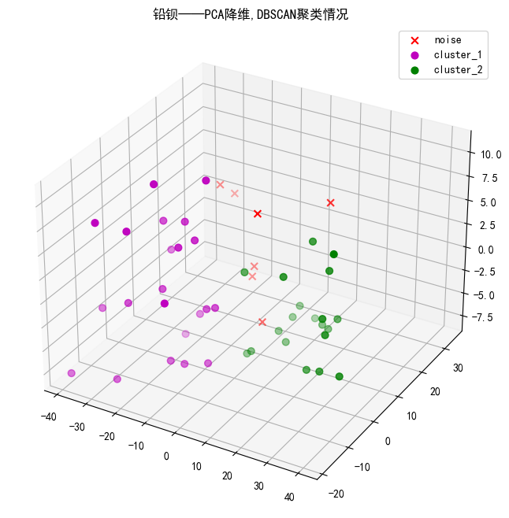

```python
DB=DBSCAN(eps=12,min_samples=3).fit(pca_trans)
pca_df['label']=DB.labels_
cluster_0=pca_df[pca_df['label']==(-1)]
cluster_1=pca_df[pca_df['label']==0]
cluster_2=pca_df[pca_df['label']==1]

fig = plt.figure(figsize=(16,8))
ax = fig.add_subplot(111, projection='3d')
ax.scatter(cluster_0.iloc[:,0],cluster_0.iloc[:,1],cluster_0.iloc[:,2],marker='x',color='red',label='noise',s=40)
ax.scatter(cluster_1.iloc[:,0],cluster_1.iloc[:,1],cluster_1.iloc[:,2],c='m',label='cluster_1',s=40)
ax.scatter(cluster_2.iloc[:,0],cluster_2.iloc[:,1],cluster_2.iloc[:,2],c='g',label='cluster_2',s=40)

plt.title('铅钡——PCA降维,DBSCAN聚类情况')
plt.legend()
plt.show()
```

## 问题3

对附件表单 3 中未知类别玻璃文物的化学成分进行分析，鉴别其所属类型，并对分类结果的敏感性进行分析。

### TensorFlow

```python
import pandas as pd
import numpy as np
raw_dataset = pd.read_csv('最终数据.csv')      #路径

np.set_printoptions(precision=3, suppress=True) #控制输出方式，precision--小数点个数，suppress=True时，小数不需要以科学计数法的形式输出
dataset = raw_dataset.copy()
dataset = dataset.iloc[:,1:16]
print(dataset.shape)
print(dataset.head())

average = np.average(dataset.values[:,:-1], axis=0) #values() 函数以列表返回字典中的所有值
variance = np.var(dataset.values[:,:-1], axis=0) #axis=0代表往跨行（down)，而axis=1代表跨列（across)，方向动词
print('均值', average)
print('方差', variance)
```

```
(67, 15)
   二氧化硅SiO2  氧化钠Na2O  氧化钾K2O  氧化钙CaO  氧化镁MgO  氧化铝Al2O3  氧化铁Fe2O3  氧化铜CuO  \
0     69.33      0.0    9.99    6.32    0.87      3.93      1.74    3.87
1     87.05      0.0    5.19    2.01    0.00      4.06      0.00    0.78
2     61.71      0.0   12.37    5.87    1.11      5.50      2.16    5.09
3     65.88      0.0    9.67    7.12    1.56      6.44      2.06    2.18
4     61.58      0.0   10.95    7.35    1.77      7.50      2.62    3.27

   氧化铅PbO  氧化钡BaO  五氧化二磷P2O5  氧化锶SrO  氧化锡SnO2  二氧化硫SO2  glass_type
0    0.00    0.00       1.17    0.00      0.0     0.39           0
1    0.25    0.00       0.66    0.00      0.0     0.00           0
2    1.41    2.86       0.70    0.10      0.0     0.00           0
3    0.00    0.00       0.79    0.00      0.0     0.36           0
4    0.00    0.00       0.94    0.06      0.0     0.47           0
均值 [49.022  0.786  1.847  2.532  0.683  4.041  0.849  1.954 24.463  7.779
  2.684  0.262  0.078  0.603]
方差 [582.464   2.693  14.824   5.324   0.417   9.267   1.369   4.952 375.068
  69.917  12.372   0.07    0.112   7.169]
```

获取测试集和训练集

```python
train_dataset = dataset.sample(frac = 0.8, random_state = 0)#pandas.DataFrame.sample 随机选取若干行，frac抽取行的比例，random_state=None,取得数据不重复
test_dataset = dataset.drop(train_dataset.index)
```

然后，我们分别获取训练集和测试集的化学成分以及分类标签值

```python
train_features = train_dataset.copy()
test_features = test_dataset.copy()

train_labels = train_features.iloc[:,-1].copy()
test_labels = test_features.iloc[:,-1].copy()

train_features = train_features.drop(['glass_type'], axis = 1)
test_features = test_features.drop(['glass_type'], axis = 1)

print(train_features.shape, train_labels.shape)
print(test_features.shape,test_labels.shape)
```

```
(54, 14) (54,)
(13, 14) (13,)
```

导入相应的python包

```python
import tensorflow as tf #深度神经网络

from tensorflow import keras #keras高级API，用于构建和训练模型，同时兼容 TensorFlow 的绝大部分功能
from tensorflow.keras import layers #keras的层,可操作层，主要包括：常用层（Core）、卷积层（Convolutional）、池化层（Pooling）、局部连接层、递归层（Recurrent）、嵌入层（ Embedding）、高级激活层、规范层、噪声层、包装层，当然也可以编写自己的层。
import matplotlib.pyplot as plt #常用的绘图模块，包含一系列绘图函数的相关函数

print(tf.__version__)
```

```
2.7.0
```

开始构建模型

```python
from numpy import array #导入数组库（array）
from numpy.random import uniform #产生随机数，从一个均匀分布[low,high)中随机采样
from numpy import hstack #堆叠数组
from sklearn.model_selection import train_test_split #分离器函数，用于将数组或矩阵划分为训练集和测试集
from sklearn.metrics import mean_squared_error #均方差
```

```python
model = tf.keras.Sequential([  # 根据情况调整模型结构，Sequential模型，可进行层的堆叠
    layers.Dense(150, input_dim = train_features.shape[1], activation = "relu"),
    layers.Dense(80, activation = "sigmoid"),
    layers.Dense(1)#Dense全连接层
])

#Dense(units,activation=None,use_bias=True,kernel_initializer='glorot_uniform',bias_initializer='zeros',kernel_regularizer=None,bias_regularizer=None,activity_regularizer=None,kernel_constraint=None,bias_constraint=None)
# units：大于0的整数，代表该层的输出维度。***
# input_dim：该层输入的维度***
# activation：激活函数，为预定义的激活函数名（参考激活函数），或逐元素（element-wise）的Theano函数。如果不指定该参数，将不会使用任何激活函数（即使用线性激活函数：a(x)=x）

# use_bias：布尔值，是否使用偏置项
# kernel_initializer：权值初始化方法，为预定义初始化方法名的字符串，或用于初始化权重的初始化器。
# bias_initializer：偏置向量初始化方法，为预定义初始化方法名的字符串，或用于初始化偏置向量的初始化器。
# regularizer：正则项，kernel为权重的、bias为偏执的，activity为输出的
# constraints：约束项，kernel为权重的，bias为偏执的。

model.compile( loss = "mse" , optimizer = "sgd" )
# keras model.compile(loss='目标函数 ', optimizer='adam', metrics=['accuracy'])
#loss目标函数，或称损失函数，是网络中的性能函数（mse就是mean_squared_error均方差）
#optimizer优化器，用于控制梯度裁剪（sgd为随机梯度下降法，支持动量参数，支持学习衰减率，支持Nesterov动量）

model.summary()#打印出模型概况，实际调用的是keras.utils.print_summary
```

```
Model: "sequential"
_________________________________________________________________
 Layer (type)                Output Shape              Param #
=================================================================
 dense (Dense)               (None, 150)               2250

 dense_1 (Dense)             (None, 80)                12080

 dense_2 (Dense)             (None, 1)                 81

=================================================================
Total params: 14,411
Trainable params: 14,411
Non-trainable params: 0
_________________________________________________________________
```

```python
myModel = model.fit(
    train_features,
    train_labels,
    epochs = 10,
    batch_size = 5,
    validation_data = (test_features,test_labels)
)
# train_features：输入数据。一个输入，类型是numpy.array
# train_labels：输出数据
# batch_size：整数，指定进行梯度下降时每个batch包含的样本数。训练时一个batch的样本会被计算一次梯度下降，使目标函数优化一步。
# epochs：整数，训练终止时的epoch值，训练将在达到该epoch值时停止，当没有设置initial_epoch时，它就是训练的总轮数，否则训练的总轮数为epochs - inital_epoch
```

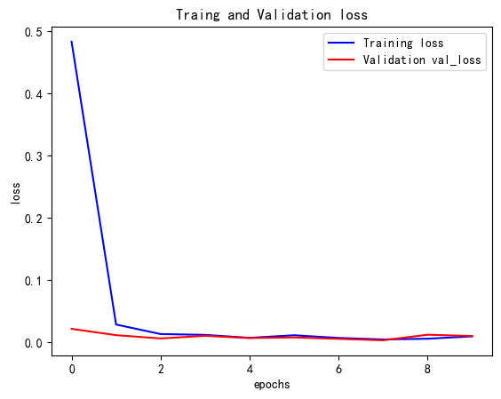

```python
#print(myModel.history)
epochs=range(len(myModel.history['loss']))

plt.figure()
plt.plot(epochs,myModel.history['loss'],'b',label='Training loss')
plt.plot(epochs,myModel.history['val_loss'],'r',label='Validation val_loss')
plt.xlabel('epochs')
plt.ylabel('loss')
plt.title('Traing and Validation loss')
plt.legend()
```

```python
test_preds = model.predict(test_features) #模型预测，输入测试集，输出预测结果
print("预测均方差MSE为:%.4f" % mean_squared_error(test_labels, test_preds))
```

```
预测均方差MSE为:0.0098
```

```python
data_third = pd.read_excel('附件.xlsx', sheet_name='表单3')
data_third = data_third.fillna(0)
data_third = data_third.iloc[:,2:]
data_third.shape
```

```
(8, 14)
```

```python
sheet3_preds = model.predict(data_third)
print(sheet3_preds)
list=[]
for i in sheet3_preds:
    i = abs(i)
    if( abs(i - 1) >= 0.5):
        list.append('高钾')
    else:
        list.append('铅钡')
print(list)
```

```
[[0.105]
 [1.078]
 [1.082]
 [1.096]
 [0.99 ]
 [0.098]
 [0.108]
 [1.227]]
['高钾', '铅钡', '铅钡', '铅钡', '铅钡', '高钾', '高钾', '铅钡']
```

```python
list = pd.DataFrame(list)
data_third['预测玻璃类型'] = list
data_third
```

|  | 二氧化硅(SiO2) | 氧化钠(Na2O) | 氧化钾(K2O) | 氧化钙(CaO) | 氧化镁(MgO) | 氧化铝(Al2O3) | 氧化铁(Fe2O3) | 氧化铜(CuO) | 氧化铅(PbO) | 氧化钡(BaO) | 五氧化二磷(P2O5) | 氧化锶(SrO) | 氧化锡(SnO2) | 二氧化硫(SO2) | 预测玻璃类型 |
| --- | --- | --- | --- | --- | --- | --- | --- | --- | --- | --- | --- | --- | --- | --- | --- |
| 0 | 78.45 | 0.0 | 0.00 | 6.08 | 1.86 | 7.23 | 2.15 | 2.11 | 0.00 | 0.00 | 1.06 | 0.03 | 0.00 | 0.51 | 高钾 |
| 1 | 37.75 | 0.0 | 0.00 | 7.63 | 0.00 | 2.33 | 0.00 | 0.00 | 34.30 | 0.00 | 14.27 | 0.00 | 0.00 | 0.00 | 铅钡 |
| 2 | 31.95 | 0.0 | 1.36 | 7.19 | 0.81 | 2.93 | 7.06 | 0.21 | 39.58 | 4.69 | 2.68 | 0.52 | 0.00 | 0.00 | 铅钡 |
| 3 | 35.47 | 0.0 | 0.79 | 2.89 | 1.05 | 7.07 | 6.45 | 0.96 | 24.28 | 8.31 | 8.45 | 0.28 | 0.00 | 0.00 | 铅钡 |
| 4 | 64.29 | 1.2 | 0.37 | 1.64 | 2.34 | 12.75 | 0.81 | 0.94 | 12.23 | 2.16 | 0.19 | 0.21 | 0.49 | 0.00 | 铅钡 |
| 5 | 93.17 | 0.0 | 1.35 | 0.64 | 0.21 | 1.52 | 0.27 | 1.73 | 0.00 | 0.00 | 0.21 | 0.00 | 0.00 | 0.00 | 高钾 |
| 6 | 90.83 | 0.0 | 0.98 | 1.12 | 0.00 | 5.06 | 0.24 | 1.17 | 0.00 | 0.00 | 0.13 | 0.00 | 0.00 | 0.11 | 高钾 |
| 7 | 51.12 | 0.0 | 0.23 | 0.89 | 0.00 | 2.12 | 0.00 | 9.01 | 21.24 | 11.34 | 1.46 | 0.31 | 0.00 | 2.26 | 铅钡 |

## 问题4

针对不同类别的玻璃文物样品，分析其化学成分之间的关联关系，并比较不同类别之间的化学成分关联关系的差异性。【相关性，热力图，显著性看SPSS的矩阵P值】

```
          0         1         2         3         4         5         6   \
0   1.000000 -0.457198 -0.876793 -0.822889 -0.602978 -0.830732 -0.687378
1  -0.457198  1.000000  0.554220  0.620628 -0.244731  0.344563 -0.023046
2  -0.876793  0.554220  1.000000  0.759379  0.386963  0.590856  0.335781
3  -0.822889  0.620628  0.759379  1.000000  0.205060  0.536369  0.457084
4  -0.602978 -0.244731  0.386963  0.205060  1.000000  0.697763  0.594784
5  -0.830732  0.344563  0.590856  0.536369  0.697763  1.000000  0.689465
6  -0.687378 -0.023046  0.335781  0.457084  0.594784  0.689465  1.000000
7  -0.465189 -0.022229  0.250670  0.423472  0.140693  0.209659  0.525686
8  -0.398057  0.359165  0.275214  0.367660  0.166376  0.422439  0.150923
9  -0.344856 -0.213569  0.092629  0.078330  0.427346  0.380576  0.451793
10 -0.447796 -0.185782  0.171173 -0.031251  0.650444  0.676068  0.765134
11 -0.525401 -0.181886  0.420829  0.034659  0.712132  0.594892  0.590544
12  0.048581 -0.106211  0.141920 -0.290069  0.261207 -0.162773 -0.219301
13 -0.357223 -0.194330  0.332395  0.428980  0.407564  0.146829  0.232485
```

[output cut: 16 more lines]

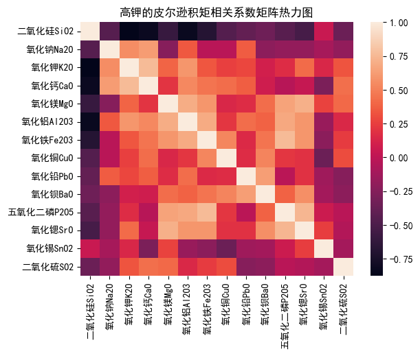

```python
import seaborn as sns

sheet2=pd.read_csv("高钾.csv")
sheet2_data=sheet2.iloc[:,1:15]

correlation_matrix = np.corrcoef(sheet2_data, rowvar=0) # 相关性分析
correlation_matrix = pd.DataFrame(correlation_matrix)
print(correlation_matrix)

plt.title('高钾的皮尔逊积矩相关系数矩阵热力图')
sns.heatmap(sheet2_data.corr())
```

```
          0         1         2         3         4         5         6   \
0   1.000000  0.361626  0.086932 -0.488252  0.087697  0.401109  0.082391
1   0.361626  1.000000 -0.058649 -0.373397  0.025719  0.102628 -0.244444
2   0.086932 -0.058649  1.000000  0.096395  0.269204  0.305767  0.247599
3  -0.488252 -0.373397  0.096395  1.000000  0.417369  0.135241  0.387489
4   0.087697  0.025719  0.269204  0.417369  1.000000  0.449918  0.293465
5   0.401109  0.102628  0.305767  0.135241  0.449918  1.000000  0.229807
6   0.082391 -0.244444  0.247599  0.387489  0.293465  0.229807  1.000000
7  -0.354419 -0.058065 -0.146388 -0.068170 -0.308957 -0.281631 -0.246980
8  -0.737612 -0.349484 -0.130797  0.356158 -0.036143 -0.441264 -0.047608
9  -0.436188 -0.056452 -0.041056 -0.124128 -0.452650 -0.339399 -0.294917
10 -0.565365 -0.395635 -0.105554  0.535134  0.272303 -0.074300  0.152629
11 -0.503199 -0.092758 -0.121148  0.170992  0.086694 -0.155264 -0.090856
12  0.085382 -0.082541  0.194767  0.209672  0.245807  0.468594  0.225548
13 -0.385775 -0.129758  0.010246  0.103686 -0.266443 -0.206045 -0.179850
```

[output cut: 16 more lines]

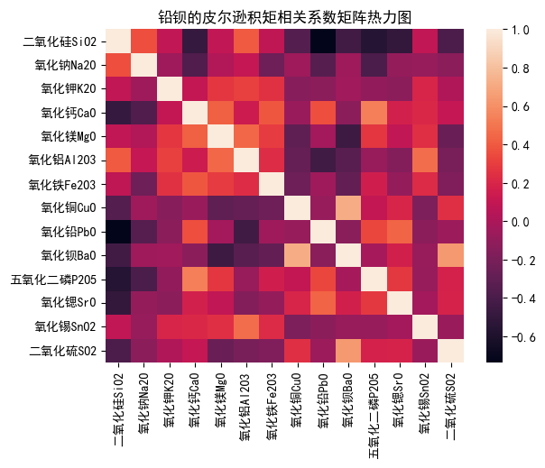

```python
sheet2=pd.read_csv("铅钡.csv")
sheet2_data=sheet2.iloc[:,1:15]

correlation_matrix = np.corrcoef(sheet2_data, rowvar=0) # 相关性分析
correlation_matrix = pd.DataFrame(correlation_matrix)
print(correlation_matrix)

plt.title('铅钡的皮尔逊积矩相关系数矩阵热力图')
sns.heatmap(sheet2_data.corr())
```